# How Long Will The Bacterial Colony Last?

## [Riddler Classic](https://fivethirtyeight.com/features/how-long-will-the-bacterial-colony-last/)

From Adam Wagner comes a curious case of colonies:

You are studying a new strain of bacteria, *Riddlerium classicum* (or *R. classicum*, as the researchers call it). Each *R. classicum* bacterium will do one of two things: split into two copies of itself or die. There is an 80 percent chance of the former and a 20 percent chance of the latter.

If you start with a single *R. classicum* bacterium, what is the probability that it will lead to an everlasting colony (i.e., the colony will theoretically persist for an infinite amount of time)?

*Extra credit:* Suppose that, instead of 80 percent, each bacterium divides with probability p. Now what’s the probability that a single bacterium will lead to an everlasting colony?

## Solution

Each *R. classicum* bacterium will do one of two things: split into two copies of itself with probability $p$ or die with probability $1-p$.

Let the probability of colony extinction be $D$. This probability is the sum of $1-p$, representing death of the initial bacterium, and $p\cdot D^2$, representing the probability that the progeny line from each offspring also goes to extinction. This yields:

$$D= (1 - p) + p\cdot D^2$$

$$0= pD^2 - D + (1 - p)$$

Factoring: $$0 = (pD - (1 - p))(D - 1)$$
$$0 = (pD + p - 1)(D - 1)$$
$$0 = (p(D + 1) - 1)(D - 1)$$

Solving the left factor: $$p(D + 1) = 1$$
$$D = \frac{1}{p}-1$$

However, in order to have an Everlasting colony, D is constrained: $$1 > \frac{1}{p} - 1 ≥ 0$$
$$2 > \frac{1}{p} ≥ 1$$
$$\frac{1}{2} < p ≤ 1$$

## Answer

For $0 ≤ p ≤ \frac{1}{2}$, $D = 1$, from the earlier right factor, meaning Extinction is certain. For $p = 0.8$, the probability of an Everlasting Colony is:

$$1 - (\frac{1}{p} - 1) = 2 - \frac{1}{p} = 2 - \frac{1}{.8} = \frac{3}{4} = 0.75$$

## Table

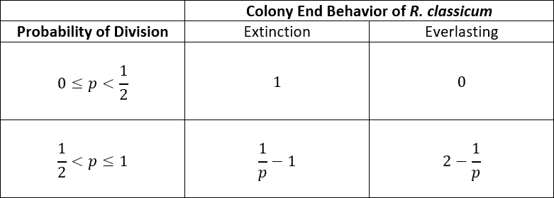

```python
from IPython.display import Image
Image(filename = 'R.Classicum.png')
```

## Plot

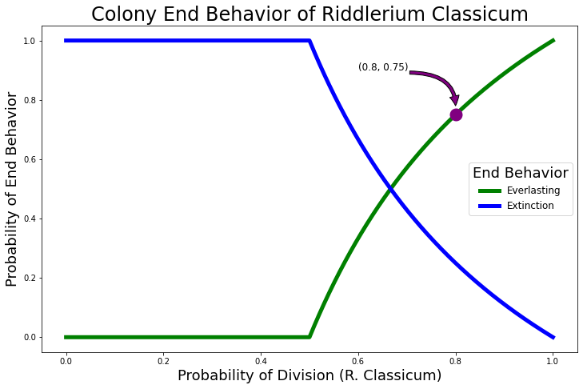

```python
#Create a list of probabilities.
xvals = [p/1000 for p in range(0, 1001)]

#Initiate empty lists.
extinction = []
everlasting = []

for x in xvals :
    if x < 0.5 :
        #Certainty for p < 1/2.
        extinction.append(1)
        everlasting.append(0)
    else :
        #Probabilities from above calculations.
        extinction.append((1 / x) - 1)
        everlasting.append(2 - (1 / x))

import matplotlib.pyplot as plt

plt.figure(figsize = (12, 7.5))
#Everlasting and Extinction lines, along with answer.
plt.plot(xvals, everlasting, c = 'green', linewidth = 5, label = "Everlasting", zorder = 1)
plt.plot(xvals, extinction, c = 'blue', linewidth = 5, label = "Extinction", zorder = 2)
plt.scatter(0.8, 0.75, c = 'purple', linewidth = 10, zorder = 3)

plt.annotate('(0.8, 0.75)',
             xy = (0.8, 0.78),
             xytext = (0.6, 0.9),
             fontsize = 12,
             arrowprops = dict(facecolor = 'purple',
                               connectionstyle = "angle3, angleA = 0, angleB = 90"))

#Set titles and axes.
plt.title("Colony End Behavior of Riddlerium Classicum", fontsize = 24)
plt.xlabel("Probability of Division (R. Classicum)", fontsize = 18)
plt.ylabel("Probability of End Behavior", fontsize = 18)
#Set legend.
plt.legend(title = "End Behavior", fontsize = 12).get_title().set_fontsize(18)
```

#### 2020.06.14 (Updated and Converted to Notebook on 2020.09.23)